# Data Programming

### *3. Distribution of Ratings*

Visualize the distribution of ratings for Netflix content.

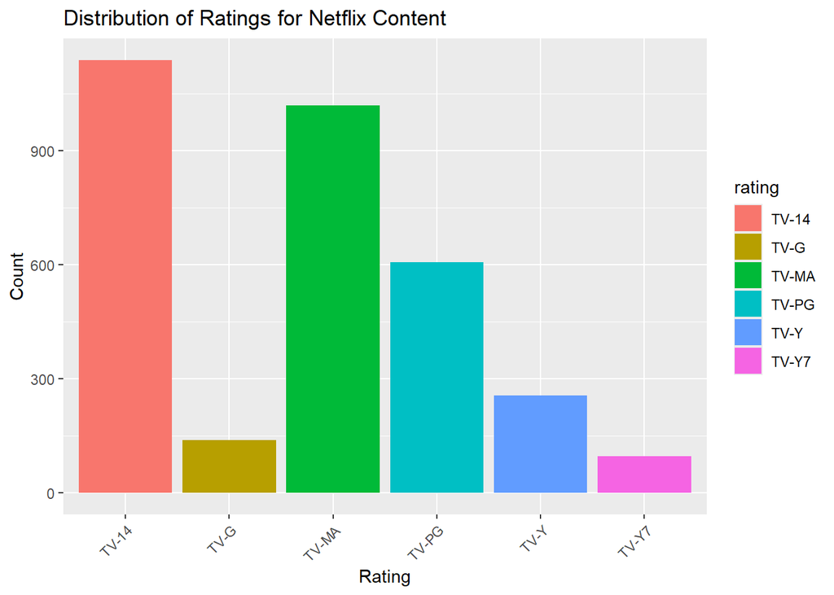

```r
plot_ratings <- ggplot(netflix_data, aes(x = rating, fill = rating)) +
  geom_bar() +
  labs(
    title = "Distribution of Ratings for Netflix Content",
    x = "Rating",
    y = "Count"
  ) +
  theme(axis.text.x = element_text(angle = 45, hjust = 1))

print(plot_ratings)
```

```r
# Using a bar plot where each bar represents a rating category, and the height of the bar represents the count of content items with that rating.
# Ratings are shown on the x-axis, and the y-axis represents the count of content items.
```

## Interpretation/Conclusion

#### Overview

The project focused on analyzing the Netflix dataset to gain insights into the distribution of content types, top countries with the most content, and the distribution of ratings.

#### Key Findings

- *Distribution of Content Types*

From the analysis, it was found that Netflix predominantly offers two types of content: Movies and TV Shows. The distribution showed that there are slightly more Movies than TV Shows available on the platform.

- *Distribution of Ratings*

The distribution of ratings for Netflix content varied, with the majority falling under categories like TV-MA (Mature Audience), TV-14 (Parents Strongly Cautioned), and TV-PG (Parental Guidance Suggested). This indicates the diverse audience preferences catered to by Netflix, ranging from family-friendly to mature content.

#### Insights and Implications

- **Content Diversity**: Netflix offers a diverse range of content types, appealing to various audience demographics globally. The balance between Movies and TV Shows ensures a broad selection for subscribers.
- **Global Content Strategy**: The dominance of content from the United States underscores Netflix’s strategy to provide a mix of local and international content, enhancing its global appeal.
- **Audience Targeting**: The distribution of ratings reflects Netflix’s efforts to cater to different audience preferences, ensuring a wide range of content suitable for various age groups and viewer preferences.

#### Limitations and Future Directions

- **Data Completeness**: The analysis assumes the dataset is comprehensive and representative. Further validation and updates to the dataset would ensure accuracy in insights.
- **Temporal Analysis**: Future studies could explore trends over time, analyzing changes in content types, ratings, and countries contributing content to Netflix.
- **User Preferences**: Incorporating user ratings and reviews could provide deeper insights into viewer preferences and satisfaction with Netflix content.

#### Conclusion

In conclusion, the project effectively explored and visualized key aspects of the Netflix dataset, providing valuable insights into content distribution, global reach, and audience preferences. The findings underscore Netflix’s role as a leading global streaming service, continually expanding its content library to cater to diverse viewer interests worldwide.

Through comprehensive data analysis and visualization techniques, this project demonstrated the capability to extract meaningful insights from large-scale datasets, offering a foundation for further research and decision-making in the entertainment industry.

## References

1.Dataset: Dang Huu Tri, Netflix Movies, Kaggle, 2024.

Hyperlink: [Netflix Movies](https://www.kaggle.com/datasets/danghuutri/netflix-movies)